# Exploring the Census Income Dataset

Group A - Autumn Class: Junylou Daniel, Oana Damian, Robin Mathew, Torsten Meyer

01 November 2020

## Business case

A well known US retail bank has an annual process for reviewing new sources of data and assessing their potential to augmenting it’s data and business intelligence capabilities. Also, the bank aims at developing methods for clustering potential new customers into several groups for the purpose of offering different types of credit cards (e.g. Platinum, Gold, Silver, Bronze). This year, among other sources of data, the data science team has the mandate of exploring US census data, potentially integrating it with existing customer data, and generating a shiny app that illustrates the clustering of existing, and potential customers.

Before effectively assessing how the US census data and its features can enhance existing bank process, the data science team had been tasked with exploring the data and presenting their findings. Management expressed an interest in:

1. understanding customers income determinants
2. profiling potential customers
3. developing a platform (shiny app) with which new and existing customers can be grouped in terms of various types of credit card offers
4. understanding if the data poses any potential ethical issues related to the presence of race and gender information

Management expectations were anchored to a well known 1994 US census dataset (https://archive.ics.uci.edu/ml/datasets/Adult) that has been cited and used to assess the determinants of personal income.

As such, the data science team has integrated both management requests and the features present in 1994 US census dataset to build a more recent dataset based on the latest US census data. On addition to the 1994 US census data the team also included geographical data that locates the customers in term of state.

## Data Analysis

### Data description

The data is extracted from the Current Population Survey (CPS), Annual Social and Economic (ASEC) Supplement conducted by the Bureau of the Census for the Bureau of Labor Statistics. The CPS-ASEC Supplement covers labor force data and supplemental data on work experience, income, noncash benefits, and migration. “The CPS is the source of the official Government statistics on employment and unemployment.”(https://www2.census.gov/programs-surveys/cps/techdocs/cpsmar20.pdf) Currently, the CPS interviews approximately 54,000 households on a monthly basis, sampled from the civilian non-institutional population of the US in approximately 1,328 counties and cities.

The survey data covers separately households, families and persons.

For households, in addition to demographic and economic data, the data also includes geographical location features.

For persons, the survey covers work experience information, employment status, occupation, industry, weeks worked and hours per week worked, reason for not working full time, total income and income components. Data on employment and income is based on the preceding year, while demographic data reflects the status at the time of the survey. Members of the armed forces are included in the ASEC if at least one civilian adult lives in the same household.

The survey material is made available by the US Census Bureau for the month of March 2020 at: https://www.census.gov/data/datasets/time-series/demo/cps/cps-asec.html

The US Census Bureau provides a detailed data description file : file:///C:/Users_Folders/YORK_MLcertificate/Assignment2/asecpub20csv/ASEC2020ddl_pub_full_fields_description.pdf

The US census data files for March 2020 are available at: https://www2.census.gov/programs-surveys/cps/datasets/2020/march/asecpub20csv.zip\

### Data features extracted from the 2020 ASEC Supplement

Compared to the 1994 sample, we were able to add geographical data to the features:

| Variable Name | Description |
| --- | --- |
| age | continuous. |
| work class | NIU/children/Armed Forces Private, Self-emp-not-inc, Self-emp-inc, Federal-gov, Local-gov, State-gov, Without-pay, Never-worked. |
| fnlwgt | weight used to produce population estimates - it reflects the probability of a person being selected for the survey, adjusted for special sampling situations and failure to obtain interviews from elig… |
| education | Bachelors, Some-college, HS-grad, Prof-school, Assoc-acdm, Assoc-voc, 9th, 7th-8th, 11th, 12th, Masters, 1st-4th, 10th, Doctorate, 5th-6th, Preschool. |
| marital status | Married-civ-spouse, Divorced, Never-married, Separated, Widowed, Married-spouse-absent, Married-AF-spouse. |
| occupation | 1)Management, business, financial, 2)Professional and related, 3)Service, 4)Sales and related, 5)Office-admin support, 6) Farming, fishing, forestry, 7)Construction, extraction, 8)Installation, mainte… |
| relationship | Wife, Husband, Own-child, Not-in-family, Other-relative, Unmarried. |
| race | White only, Black only, Hawaiian/Pacific Islander only, American Indian/Alaskan Native only, Asian only, Black & Other, White & Other, Other 2 races, Other 3+ races |
| gender | Female, Male. |
| native country | given the numerous categories (approximately 150 countries), the countries available were grouped based on cultural proximity, following Mensah Chen(2013). US, China, Mexico and India remain separate … |
| capital gain | continuous. |
| hours per week | -4(hours vary), 0-99 hours per week. |
| wages & salary | numerical |
| metropolis size | NIU/non-metropolitan, 100,000-249,999, 250,000-499,999, 500,000-999,999, 1,000,000-2,499,999, 2,500,000-4,999,999, 5,000,000+ |
| state | the 52 US states |
| School enrolment | flags if a person is enrolled in school in the moment of the survey |

Similar to the 1994 US census adult population extract, the March 2020 data excludes children (US Census fields A_HGA~=0 and A_AGE>16), it excludes persons who have no occupation or are children (US Census field A_MJOCC~=0) and persons who have an assigned population weight of zero (US Census field A_FNLWGT~=0)

### Descriptive statistics

```
## [1] 50000
```

```
## [1] "Both work sector and ocupation have an impact on the distribution of the level of income."
```

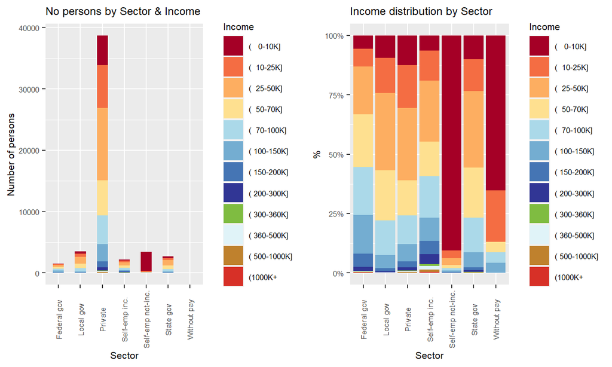

```
## [1] ""
```

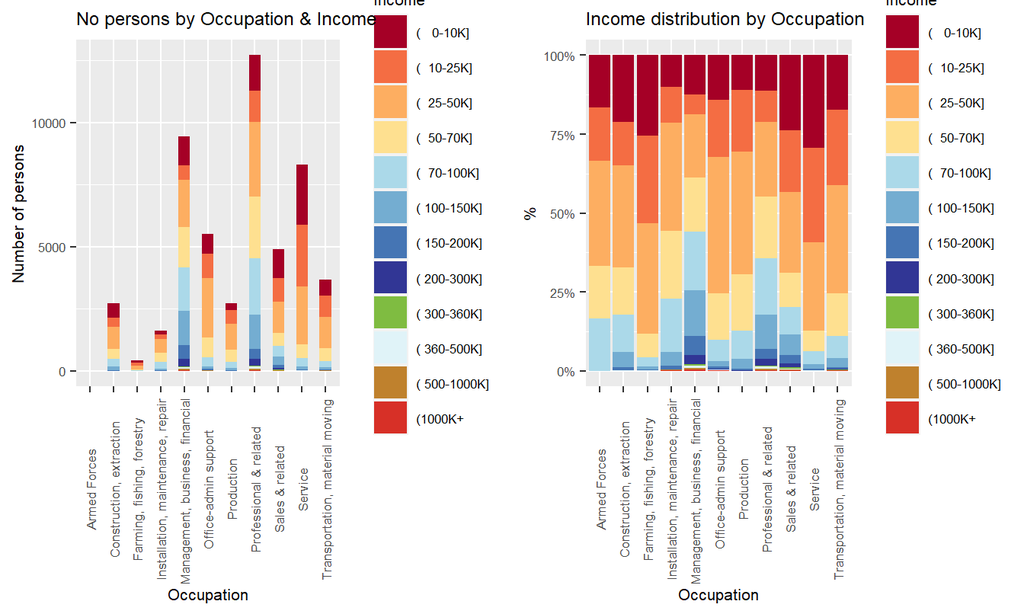

```
## [1] ""
```

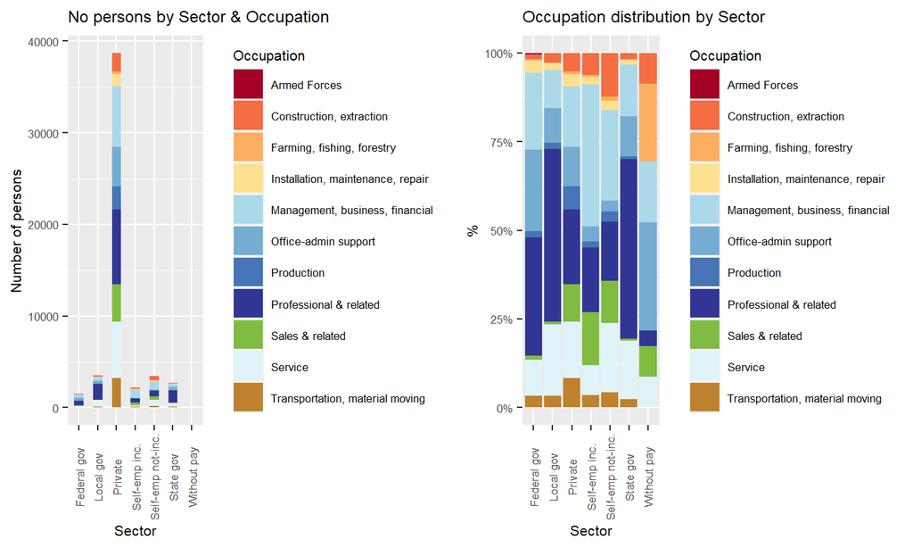

```
## [1] "Age has a clear impact on the income distribution. Between 36y and 55y age groups,  income distribution seems similar but from ages 16 to 35  and from ages 56 onawrd the dictribution of income changes significantly from one age group to teh next"
```

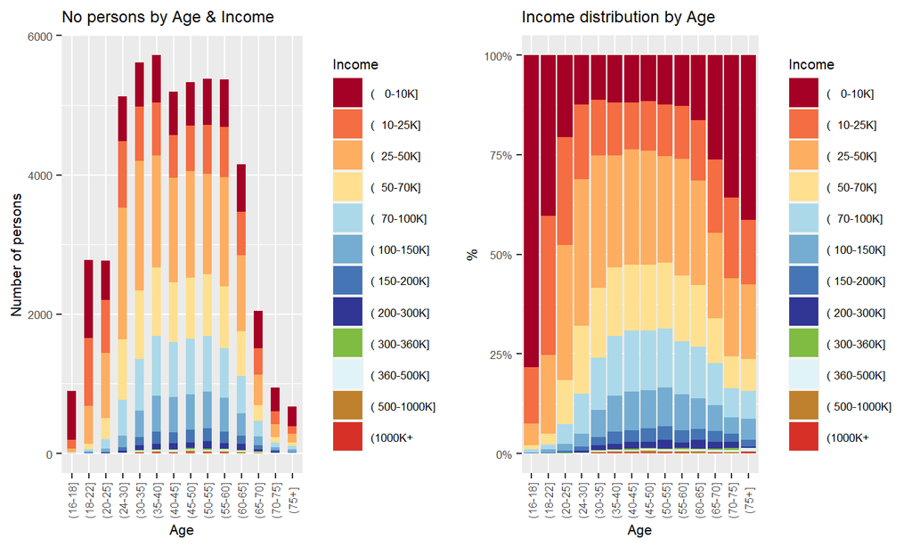

```
## [1] "A clear pattern emerges for the distribution of income across gender types - of the persons generating an annual income above 100K, there is a clear more frequent presence of men vs women, peakng at the (200k-300k] brachet where men are 75% of the observed sample population"
```

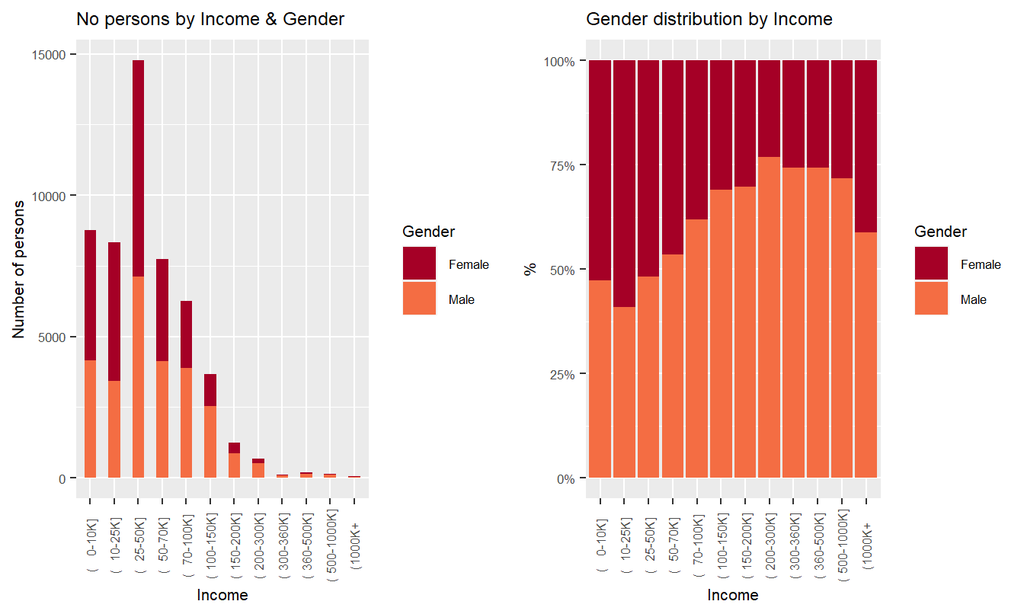

```
## [1] "The propoportion of men to women is significantly dependednt on the sector of activity. We remark the high ptpoportion of women  relative to men in teh non-pay category."
```

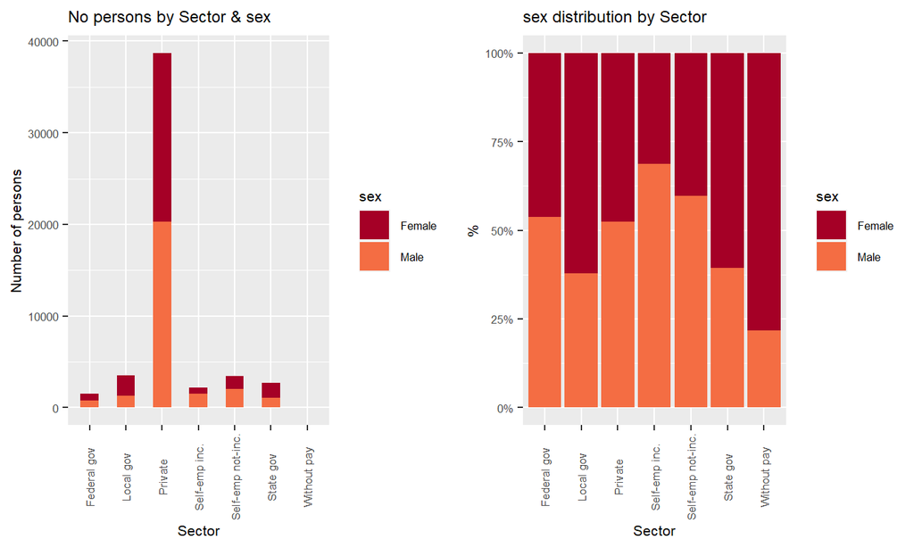

```
## [1] "The propoportion of men to women is significantly dependednt on the ocupation, with office admin. jobs dominated by women and construction and maintenance dominated by men."
```

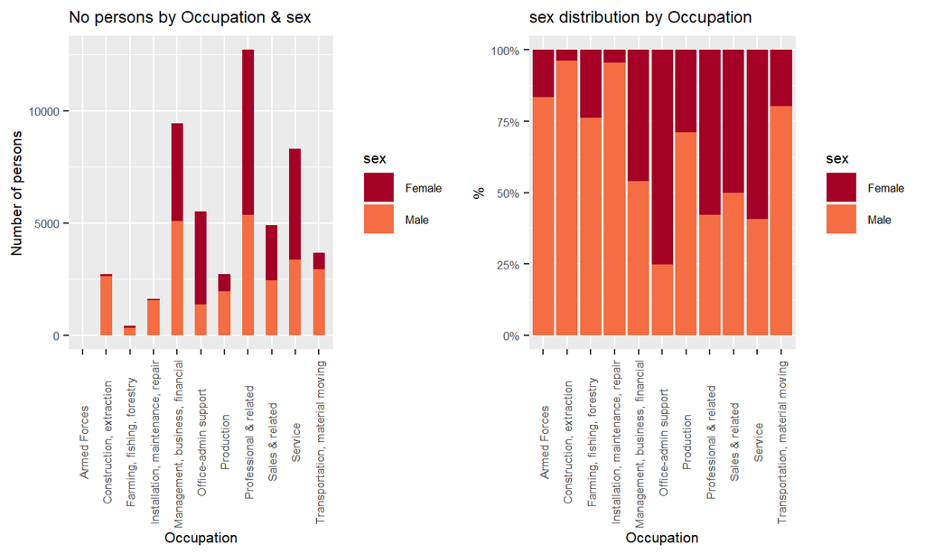

[output not shown]

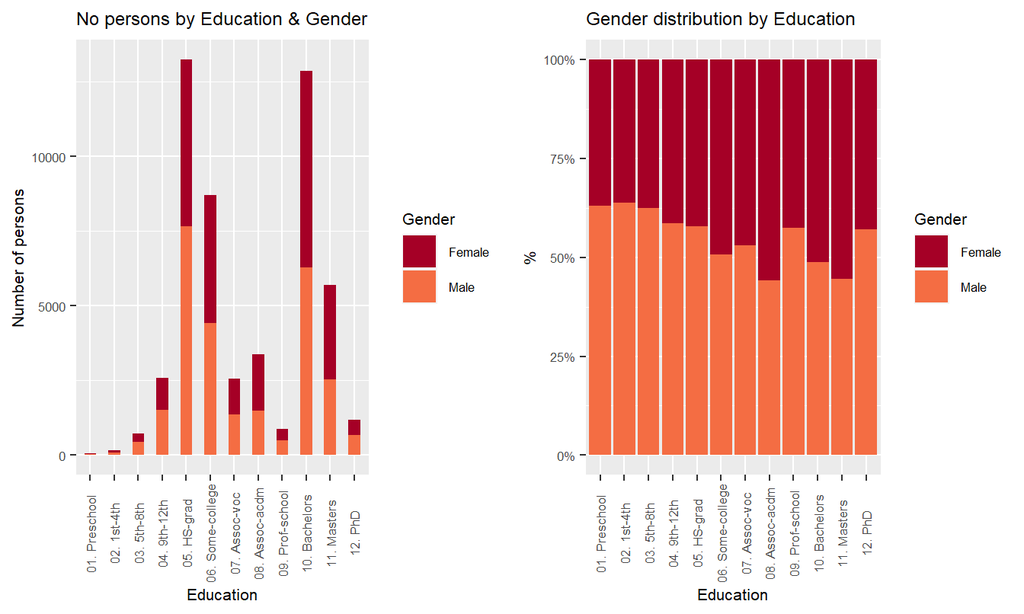

```
## [1] "In the distribution of income, as expected, higher education is correlated with higher income. Interestingly, the income distribution for persons with a PhD and persons with a professional school seem quite similar."
```

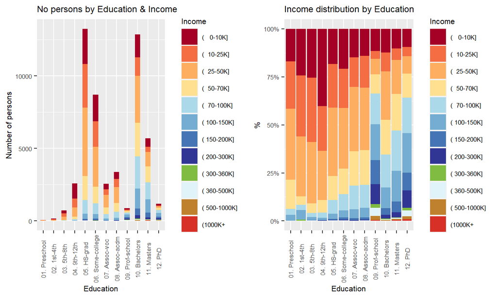

[output not shown]

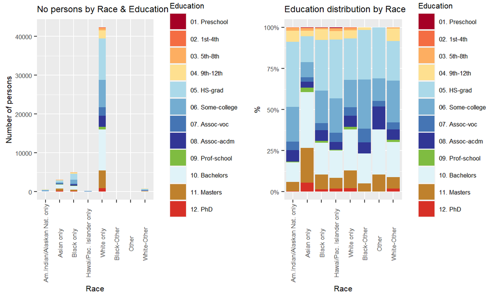

[output not shown]

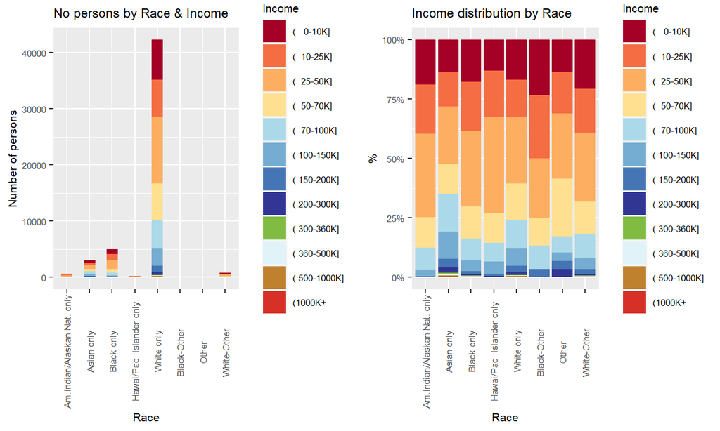

```
## [1] "The native culture has a significant impact on the distribution of education."
```

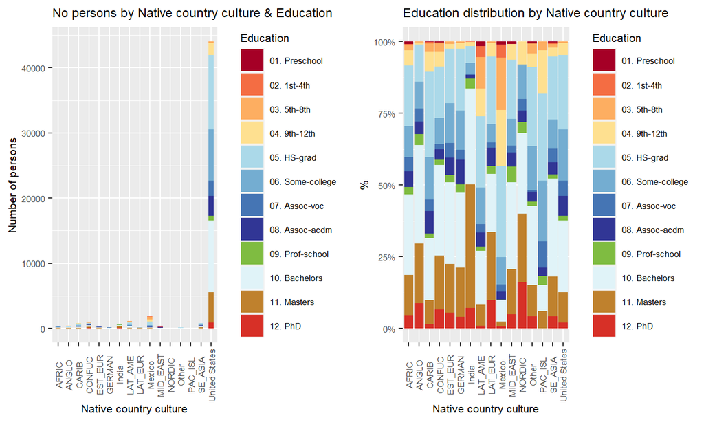

```
## [1] "The native culture has a significant impact on the distribution of income."
```

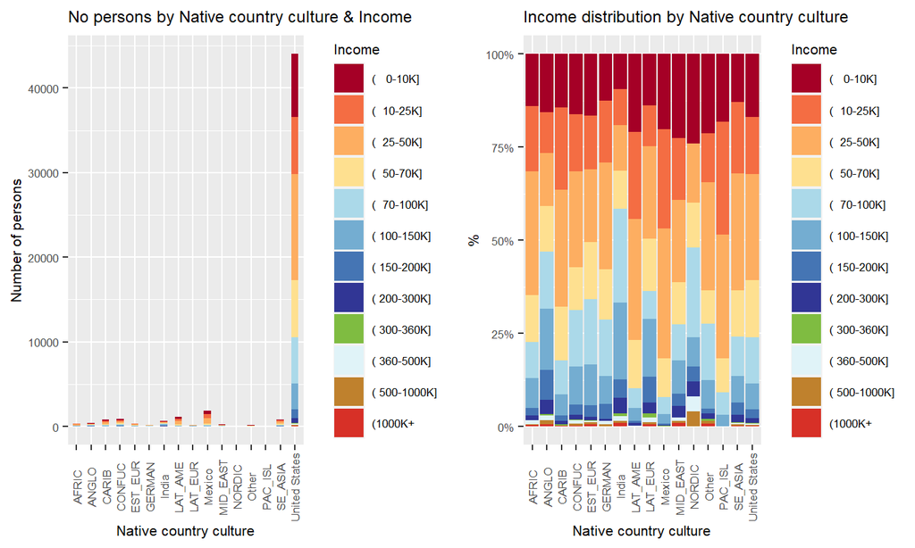

```
## [1] "The pattern in the distribution of income by type of metropole is as expected, the larger the metropole, the icome distribution tends to move towards higher income brackets"
```

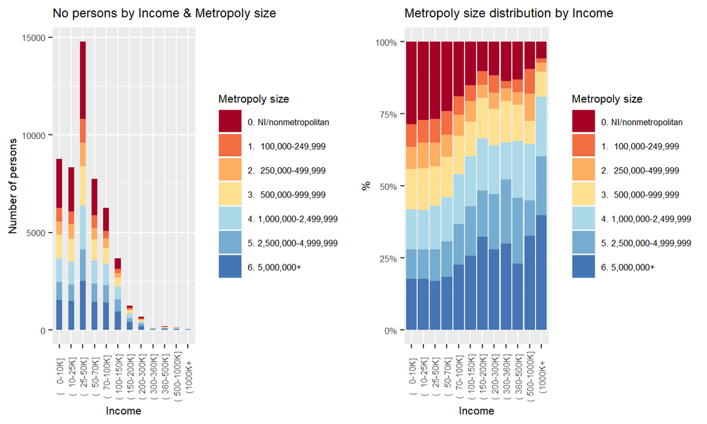

```
## [1] "We observe that East South central, Mountain, West North central and West South central tend to have a distribution shifted to lower income."
```

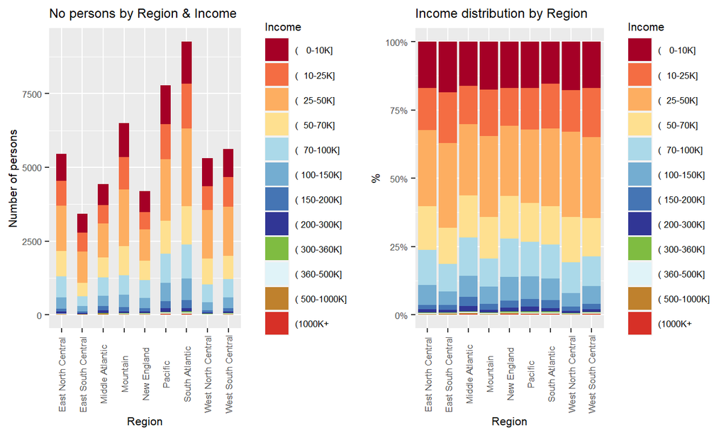

```
## [1] "Aligned with the region observation, one can observe that there are potentially important disparities in the distribution of income across states."
```

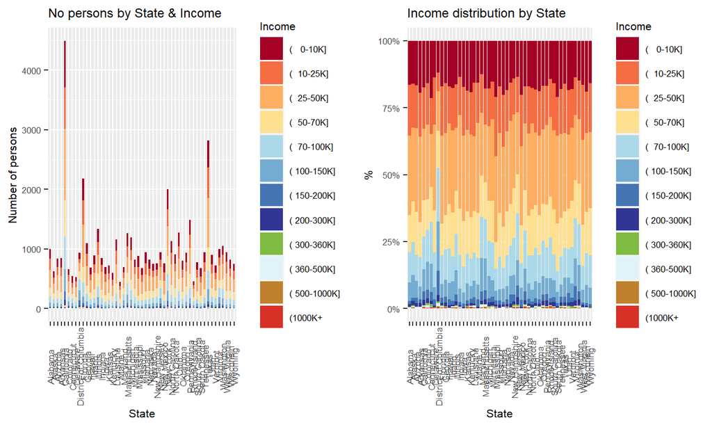

## Data exploration

The features available are a collection opf numerical and categorical variables. For clustering, various methods exist, more or less adapted to categorical variables. We explore the following 3 algorithms: *.* K-means *.* K-medoids or PAM clustering *.* Agglomerative Hierarchical Clustering

### Profile clusterings with K-means

“K-means clustering is a method of vector quantization, originally from signal processing, that aims to partition the available observations into K clusters in which each observation belongs to the cluster with the nearest mean (cluster centers or cluster centroid), serving as a prototype of the cluster”(Source:https://en.wikipedia.org/wiki/K-means_clustering). The method is applicable to observations characterized by numerical variables and is sensitive to the relative scale of the variables as well as outliers.

The method is not adapted well to categorical variables as it needs simplifying assumptions related to the scale and order of importance of the categories of each feature/variable, and the importance of each feature/variable relative to any other feature.

To be able to explore the method for learning purposes, we have employed those assumptions:

1. assigned a random order(1 to n) to the categories of each feature/variable and assumed that each category is equally different from the next and
2. each feature is considered to be equally important which made us scale the features/variables to have a variance of 1

The results for the method are generated extremely fast(less than 1 min) for the 52,000 observations and 15 features we have explored.

The K-means algorithm optimizes for the cluster centers given a certain number of clusters. To select an optimal number of clusters, the Within groups sum of squares (WSS) graph is usually used (as the number pf clusters increases, the WSS decreases at a smaller and smaller pace) coupled with business intuition (too many clusters may not be easily interpretable).

We employed a preliminary version of K-means where certain variables are binned, income, capital gains, age, hours per week. (Please see graphs below). The results are very similar.

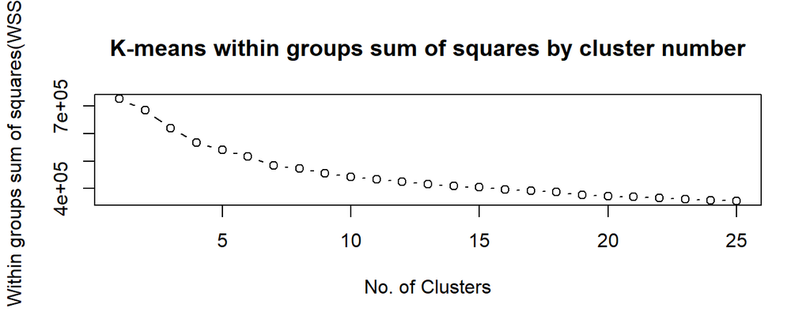

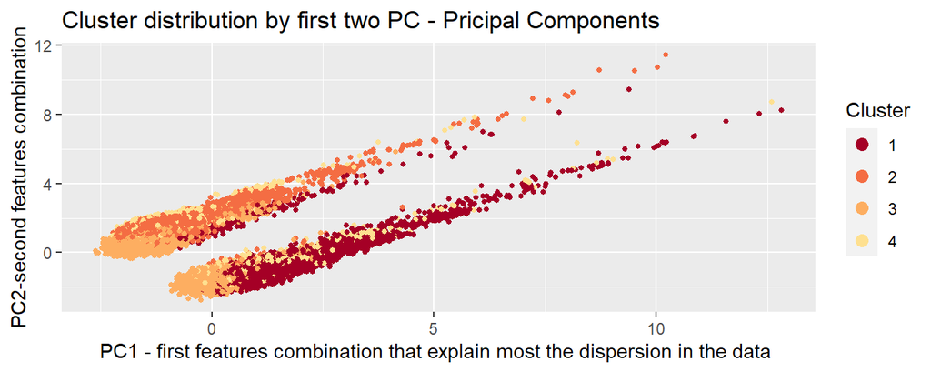

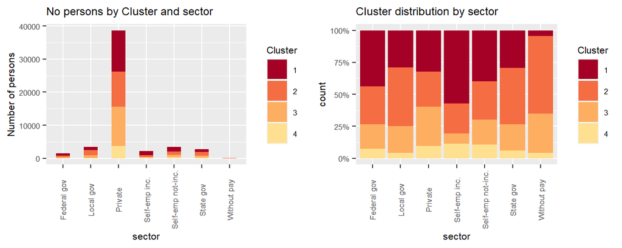

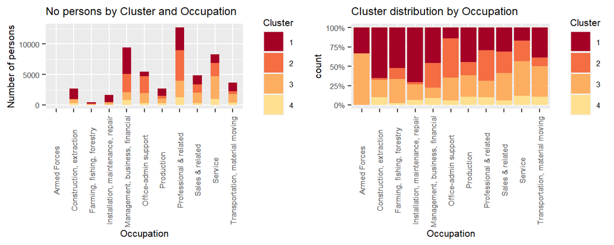

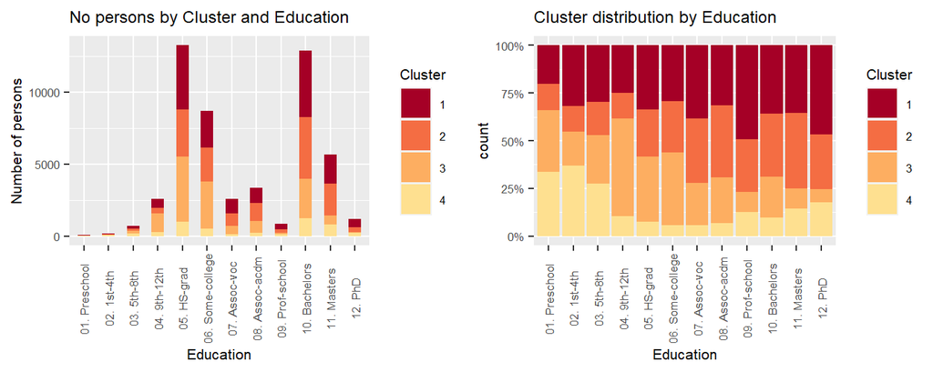

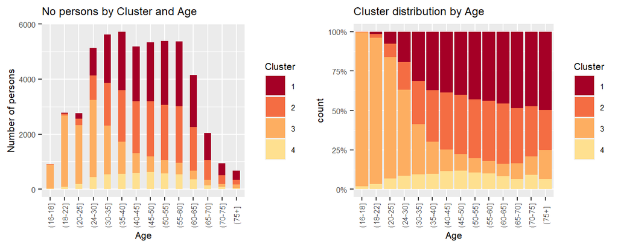

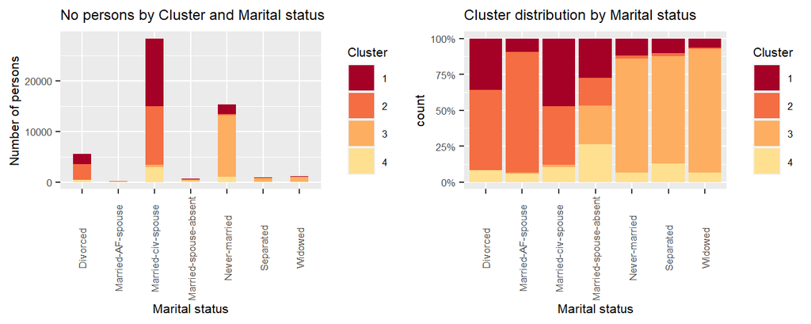

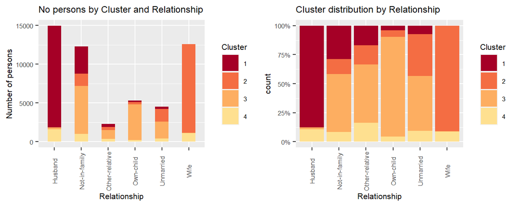

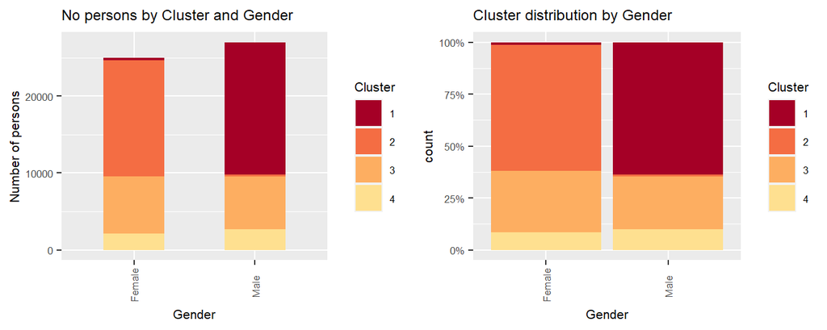

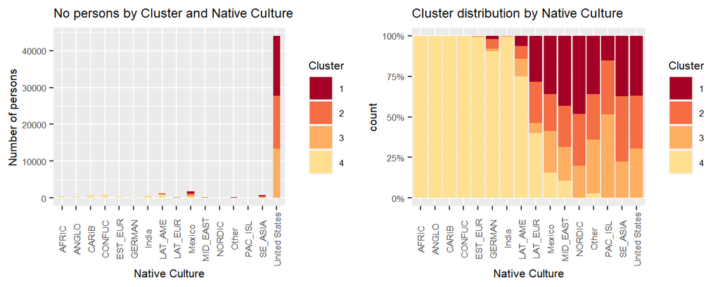

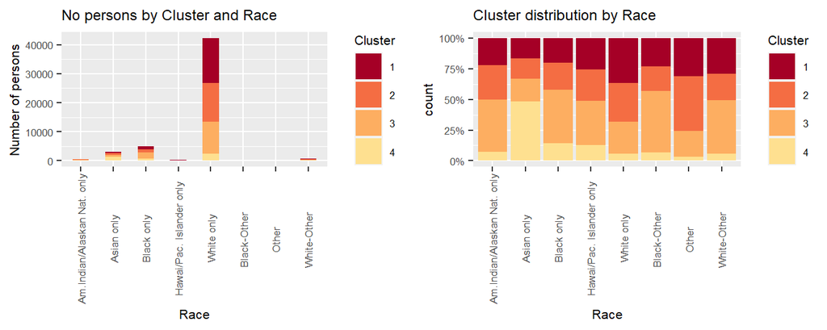

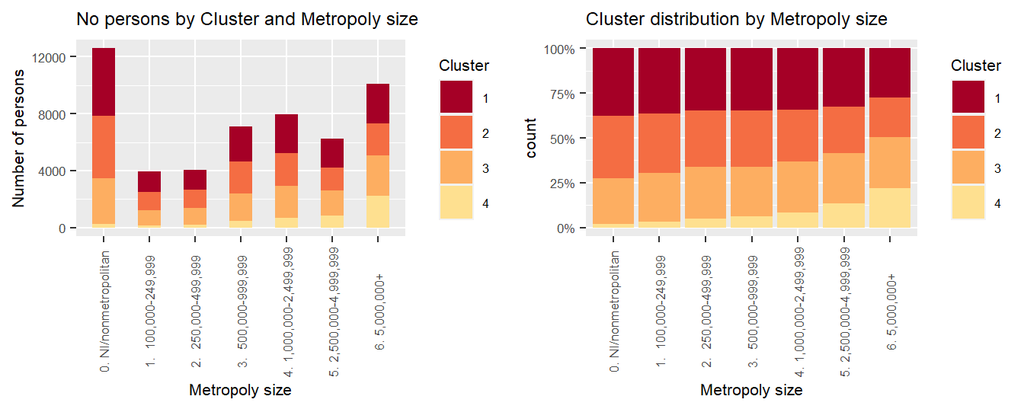

[4 more figures not shown]

#### Dissimilarity matrix

Before we start clustering our data points, we need to calculate the dissimilarity (or similarity) matrix first. Since our variables include continuous and categorical, we will use Gower distance. We will also check our dissimilarity matrix by looking at the most similar (nearest) and most dissimilar (farthest) pair of the data.

```
## [1] "Most similar pair"
```

```
##           sex occupation workclass   education marital_status relationship
## 11899  Female    Service   Private 05. HS-grad  Never-married    Own-child
## 41452  Female    Service   Private 05. HS-grad  Never-married    Own-child
##              race native_country        metropoly_size      state
## 11899  White only  United States 0. NI/nonmetropolitan   Illinois
## 41452  White only  United States 0. NI/nonmetropolitan New Mexico
##       Wages_n_salary_bins age_bins capital_gains_bins hours_per_week_bins
## 11899          (  25-50K]  (20-25]                  0            (35-40h]
## 41452          (  25-50K]  (20-25]                  0            (35-40h]
```

```
## [1] "Most dissimilar pair"
```

```
##           sex                 occupation workclass     education
## 2167    Male      Professional & related State gov 10. Bachelors
## 37789  Female Farming, fishing, forestry   Private   05. HS-grad
##           marital_status  relationship        race native_country
## 2167       Never-married Not-in-family  Asian only        SE_ASIA
## 37789 Married-civ-spouse          Wife  White only  United States
##               metropoly_size         state Wages_n_salary_bins age_bins
## 2167  5. 2,500,000-4,999,999 Massachusetts          (   0-10K]  (20-25]
## 37789  0. NI/nonmetropolitan       Montana          (  10-25K]  (55-60]
##       capital_gains_bins hours_per_week_bins
## 2167                   0            (15-20h]
## 37789                  0            Variable
```